# Logging Lab

Eric Marcon

2023-11-09

# Package installation

We will use the LoggingLab package for R (Badouard et al. 2024) to simulate reduced-impact logging in a tropical forest. The package must be installed from its Github repository because it is not on CRAN yet.

```r
# Install the latest dev version
remotes::install_github("EricMarcon/LoggingLab", ref = "em")
# To be changed for
# remotes::install_github("VincyaneBadouard/LoggingLab")
# after merging
```

# Data

## Inventory

The inventory of Paracou plot 6 is available.

```r
library("LoggingLab")
data(Paracou6_2016)
# Show the data
Paracou6_2016 %>%
  head()
```

```
##    Forest Plot PlotArea SubPlot idTree Protocole Xfield Yfield     Xutm
## 1 Paracou    6     6.25       1 100726   Guyafor   13.5  201.0 286420.1
## 2 Paracou    6     6.25       1 100729   Guyafor   19.0  196.5 286426.4
## 3 Paracou    6     6.25       1 100739   Guyafor   13.5  182.0 286424.8
## 4 Paracou    6     6.25       1 100741   Guyafor    9.5  179.5 286421.6
## 5 Paracou    6     6.25       1 100747   Guyafor   14.5  167.5 286429.3
## 6 Paracou    6     6.25       1 100750   Guyafor   18.0  169.0 286432.3
##       Yutm UTMZone      Lat       Lon           Family    Genus     Species
## 1 583135.4      22 5.272669 -52.92713       Annonaceae  Oxandra    asbeckii
## 2 583132.2      22 5.272642 -52.92707         Fabaceae   Eperua grandiflora
## 3 583116.8      22 5.272502 -52.92709         Fabaceae    Bocoa prouacensis
## 4 583113.4      22 5.272471 -52.92712     Celastraceae Maytenus    sp.1-CAY
## 5 583102.9      22 5.272376 -52.92705 Chrysobalanaceae  Licania membranacea
## 6 583105.2      22 5.272397 -52.92702 Chrysobalanaceae  Licania   canescens
##   BotaSource BotaCertainty           VernName CensusYear CensusDateCertainty
## 1       Bota             4             muamba       2016                TRUE
## 2       Bota             4 Eperua grandiflora       2016                TRUE
## 3       Bota             4               boco       2016                TRUE
## 4       Bota             3         lebi tongo       2016                TRUE
## 5       Bota             4         santi koko       2016                TRUE
## 6       Bota             4         santi koko       2016                TRUE
##   CodeAlive MeasCode  Circ CircCorr CorrCode
## 1      TRUE        0  39.5     39.5        0
## 2      TRUE        0 114.0    114.0        0
## 3      TRUE        0  48.0     48.0        0
## 4      TRUE        0 123.0    123.0        0
## 5      TRUE        0  54.0     54.0        0
## 6      TRUE        0  88.0     88.0        0
```

Columns required by the package are:

- `Forest`: the forest name to apply the corresponding volume formula.
- `idTree`: a unique identifier for each tree.
- `Xutm` and `Yutm`: the coordinates of each tree.
- `CodeAlive`: alive or dead tree.
- `Family`, `Genus`, `Species`: botanical data.
- `CircCorr`: circumference of each tree.

## Plot mask

The plot mask sets the limits of the area to log.

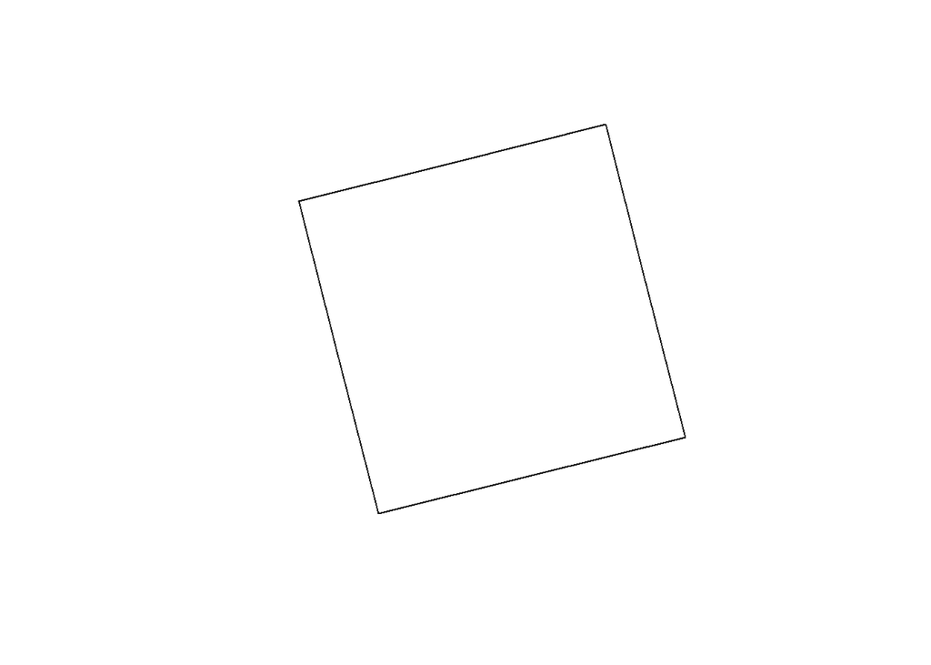

```r
library(sp)
plot(PlotMask)
```

## Species data

`SpeciesCriteria` contains data specific to each species:

```r
SpeciesCriteria %>%
  head()
```

```
## # A tibble: 6 × 8
##   CommercialName  Genus  Species CommercialLevel MinFD UpMinFD MaxFD Aggregative
##   <chr>           <chr>  <chr>             <dbl> <dbl>   <dbl> <dbl> <lgl>
## 1 st martin rouge Andira spp                   2    55      60   120 FALSE
## 2 bamba apici     Aniba  spp                   2    55      60   120 FALSE
## 3 bagasse         Bagas… guiane…               2    55      60   120 FALSE
## 4 assao           Baliz… pedice…               2    55      60   120 FALSE
## 5 dokali          Brosi… parina…               2    55      60   120 FALSE
## 6 satiné rubané   Brosi… rubesc…               2    55      60   120 FALSE
```

Columns are:

- `CommercialLevel`: Economic interest level. 1: principal economic species, 2 or more: species logged in a objective of diversification, 0: species whose genus is covered by a commercial name, but which are not logged.
- `MinFD`: Minimum Felling Diameter, in centimeters.
- `UpMinFD`: Enhanced Minimum Felling Diameter (over-rich stand case), in centimeters.
- `MaxFD`: Maximum Felling Diameter, in centimeters.
- `Aggregative`: Aggregative character of the species. It `TRUE`, isolated trees will not be logged.

## Volume Parameters Table

`ForestZoneVolumeParametersTable` contains the allometry parameters to compute.

$$Volume = aCoef + bCoef \times
DBH^2$$

```r
ForestZoneVolumeParametersTable %>%
  head()
```

```
##            Forest    Zone     aCoef    bCoef
## 1       Acarouany    West -0.061776  8.83580
## 2           BAFOG    West -0.061776  8.83580
## 3             Kaw    East -0.084516 10.46132
## 4         Laussat    West -0.061776  8.83580
## 5  Montagne_Plomb Central -0.035829  8.76340
## 6 Montagne_Tortue    East -0.084516 10.46132
```

## Scenarios

Scenarios gather the main management parameters.

They are use to define the harvestable area, the trees to log and the modelling of secondary tracks.

```r
data(ScenariosTable)
ScenariosTable
```

```
## # A tibble: 6 × 6
##   Type     SpatialDataType Objective Diversification Winching DirectionalFelling
##   <chr>    <chr>           <chr>     <lgl>           <fct>    <fct>
## 1 RIL1     SRTM            20-25     FALSE           0        0
## 2 RIL2bro… LIDAR           20-25     FALSE           0        0
## 3 RIL2     LIDAR           20-25     FALSE           1        0
## 4 RIL3     LIDAR           25-30     TRUE            2        2
## 5 RIL3fuel LIDAR           25-30     TRUE            2        2
## 6 RIL3fue… LIDAR           25-30     TRUE            2        2
```

Columns are:

- `Type`: The name of the scenario.
- `SpatialDataType`: the type of spatial data (Lidar or SRTM).
- `Objective`: Objective volume per hectare.
- `Diversification`: Allow logging other species in addition to the main commercial ones.
- `Winching`: Winching method. No cable or grapple = “0”, only cable = “1”, grapple + cable = “2”.
- `DirectionalFelling`: “0” = unused, “1” = only to avoid damage to future and reserve trees, “2” = avoid damage to future and reserve trees + trail orientation.

All functions allow `scenario = "manual"`: then, all arguments must be added manually. Their name is the same as that of columns.

# Detailed Logging simulation

## Validate the inventory

Trees that are not in the logged area or are too small to be considered are deleted.

```r
Paracou6_2016 %>%
  # Check the required columns are available
  inventorycheckformat() %>%
  # Retain trees that may be logged
  cleaninventory(PlotMask, loggingparameters()) ->
  inventory
```

`loggingparameters()` sets all logging parameters. See its help. Default values are those used in French Guiana.

## Compute tree dimensions

Compute tree dimensions (tree, trunk and crown height, crown diameter, harvestable volume, wood density, and AGB).

```r
inventory %>%
  addtreedim(volumeparameters = ForestZoneVolumeParametersTable) ->
  inventory
```

## Main skidding trails

Generate the main trail of the inventoried plot, as lines at the edge and outside of the plot.

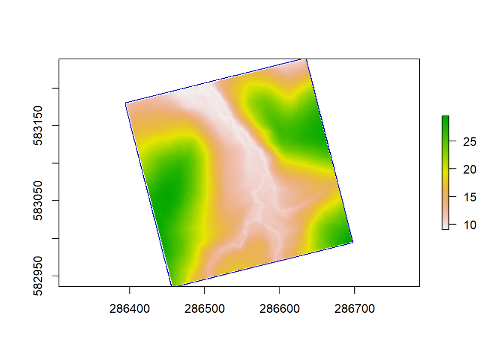

```r
MainTrails <- maintrailextract(DTMParacou)
library("sp")
plot(DTMParacou)
plot(MainTrails, add = TRUE)
```

## Harvestable area definition

Define harvestable zones and machine-accessible zones within the plot.

By default, a prospecting unit is an area connected to a truck trail or a main skid trail, with a slope of less than 27%, avoiding lowlands and the water system (30 m buffer).

We use a manual scenario to be able to change the arguments easily. Winching is set to 2, i.e. grapple is used if possible (6m span), cable is used up to 40m.

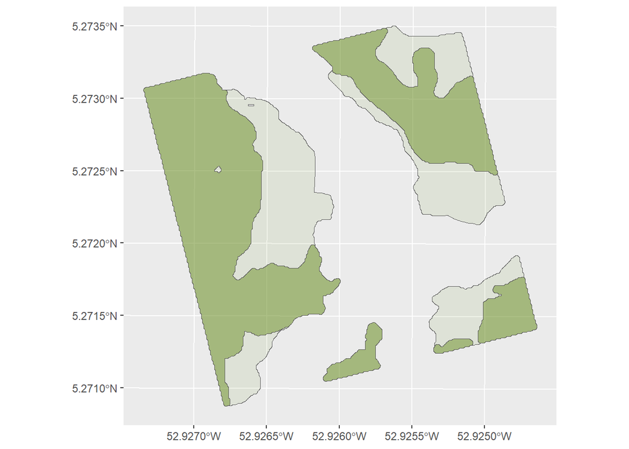

```r
HarvestableArea <- harvestableareadefinition(
  topography = DTMParacou,
  creekverticaldistance = CreekDistances$distvert,
  creekhorizontaldistance = CreekDistances$disthorz,
  maintrails = MainTrails,
  plotmask = PlotMask,
  scenario = "manual",
  winching = "2",
  advancedloggingparameters = loggingparameters()
)

# Plot
ggplot() +
  # Harvestable zones
  geom_sf(
    data = HarvestableArea$HarvestablePolygons,
    fill = "olivedrab", alpha = 0.1
  ) +
  geom_sf(
    data = HarvestableArea$MachinePolygons,
    fill = "olivedrab", alpha = 0.5
  ) ->
  LoggingMap
LoggingMap
```

Light green areas are harvestable. Dark green ones are harvestable by machines.

Compare with the slopes.

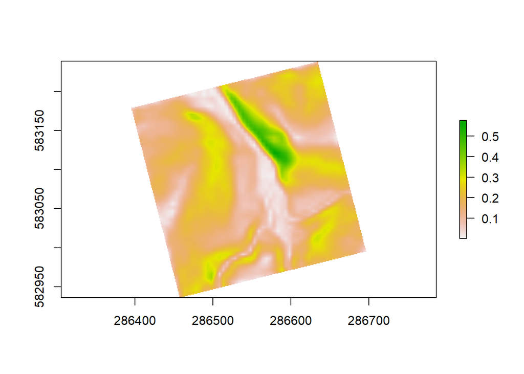

```r
plot(HarvestableArea$PlotSlope)
```

## Tree selection

Select trees to harvest, and future and reserve trees.

Trees are harvestable if:

- They belong to species of first economic rank or more if diversification.
- DBH is between the MinFD and the MaxFD.
- They are not isolated (>100m by default) from other individuals of the same species in the aggregative species case.
- They are located on slopes < 22%.
- They are off the main trails.

If the harvestable volume is higher than the objective volume, and that diversification was not chosen, MinFD of the first economic rank species only is increased. If diversification is allowed, MinFD of first and second economic level species is increased. Then, the trees to be harvested are chosen in decreasing order of volume, until the objective volume is reached.

If the harvestable volume is too low, diversification can be applied (`specieslax = TRUE`): trees of all commercial ranks are selected in decreasing order of volume until the objective volume is reached, or harvesting can continue despite an unreached objective volume, or be abandoned (`objectivelax = FALSE`).

```r
inventory %>%
  # Include commercial criteria to the inventory
  commercialcriteriajoin(SpeciesCriteria) ->
  inventory

inventory %>%
  treeselection(
    topography = DTMParacou,
    speciescriteria = SpeciesCriteria,
    scenario ="manual",
    objective = 30,
    fuel = "2",
    winching = "2",
    diversification = TRUE,
    specieslax = FALSE,
    objectivelax = TRUE,
    harvestablearea = HarvestableArea$HarvestableArea,
    plotslope = HarvestableArea$PlotSlope,
    maintrails = MainTrails,
    harvestablepolygons = HarvestableArea$HarvestablePolygons,
    advancedloggingparameters = loggingparameters()
  ) ->
  TreeSelection
```

## Secondary skidding trails layout

Starting from the main skidding trails, draw secondary skidding trails on the zones accessible to the machines, allowing to collect the selected trees with the chosen machines (argument `winching`). The layout is optimised to reduce the distance covered while respecting topographical constraints and avoiding trees to protect.

Skidding trails (main, secondary) allow timber to be transported from the stand to truck roads.

The secondary skidding trails:

- are 4 m wide (`ScndTrailWidth`),
- have 22% maximum slope in length (`MaxTrailCenterlineSlope`),
- have 4% maximum side slope, taken into account if Lidar data if available (`MaxTrailCrossSlope`).

They avoid:

- the trees to be logged
- the trees with a DBH of more than 50 cm (`BigTrees`)
- the reserved trees.

They join, in decreasing order of priority:

1. groups in decreasing order of tree abundance,
2. those with the shortest distance to the nearest track.

The `scenario` argument may be:

- RIL1/RIL2broken: trails go to the base of trees.
- RIL2: cable only i.e. trails go up to a maximum of 40 m (`CableLength`) from trees.
- RIL3/RIL3 including fuel: grapple is used from trails with longitudinal slope <20% (`GrappleMaxslope`). Trails go up to 6 m (`GrappleLength`) from the trees. Cable is used only when the longitudinal slope is greater than 20% or when the tree to be skidded is isolated from other trees to be exploited, from 6 to 40 m. Trails must be less than 40 m (`CableLength`) from the trees.

```r
ScndTrailOutputs <- secondtrailsopening(
  topography = DTMParacou,
  plotmask = PlotMask,
  maintrails = MainTrails,
  plotslope = HarvestableArea$PlotSlope,
  harvestablepolygons = HarvestableArea$HarvestablePolygons,
  machinepolygons = HarvestableArea$MachinePolygons,
  treeselectionoutputs = TreeSelection,
  scenario = "manual",
  winching = "2",
  fuel = "2",
  advancedloggingparameters = loggingparameters()
)
inventory <- ScndTrailOutputs$inventory
```

## Maps

Easy-to-use mapping functions are not in the package yet. We use `sf` objects and `ggplot()`.

First, prepare an `sf` for all types of trees.

```r
inventory %>%
  filter(LoggingStatus == "non-harvestable") %>%
  st_as_sf(coords = c("Xutm", "Yutm")) %>%
  st_set_crs(st_crs(SecondaryTrails$MainTrailsAccess)) ->
  NonHarvestable

inventory %>%
  filter(LoggingStatus == "harvestable") %>%
  st_as_sf(coords = c("Xutm", "Yutm")) %>%
  st_set_crs(st_crs(SecondaryTrails$MainTrailsAccess)) ->
  Harvestable

inventory %>%
  filter(LoggingStatus == "reserve") %>%
  st_as_sf(coords = c("Xutm", "Yutm")) %>%
  st_set_crs(st_crs(SecondaryTrails$MainTrailsAccess)) ->
  Reserve

inventory %>%
  filter(LoggingStatus == "future") %>%
  st_as_sf(coords = c("Xutm", "Yutm")) %>%
  st_set_crs(st_crs(SecondaryTrails$MainTrailsAccess)) ->
  Future
```

Plot non-harvestable trees.

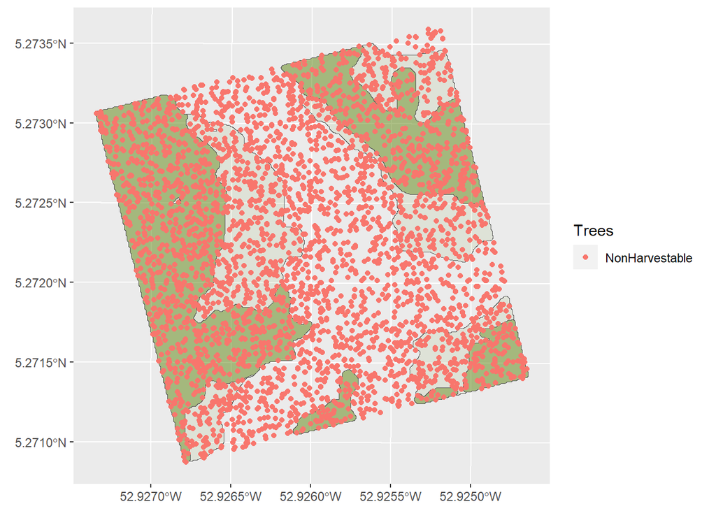

```r
LoggingMap +
  geom_sf(
    data = NonHarvestable,
    aes(colour = "NonHarvestable")
  ) +
  labs(colour = "Trees")
```

Plot the harvestable trees.

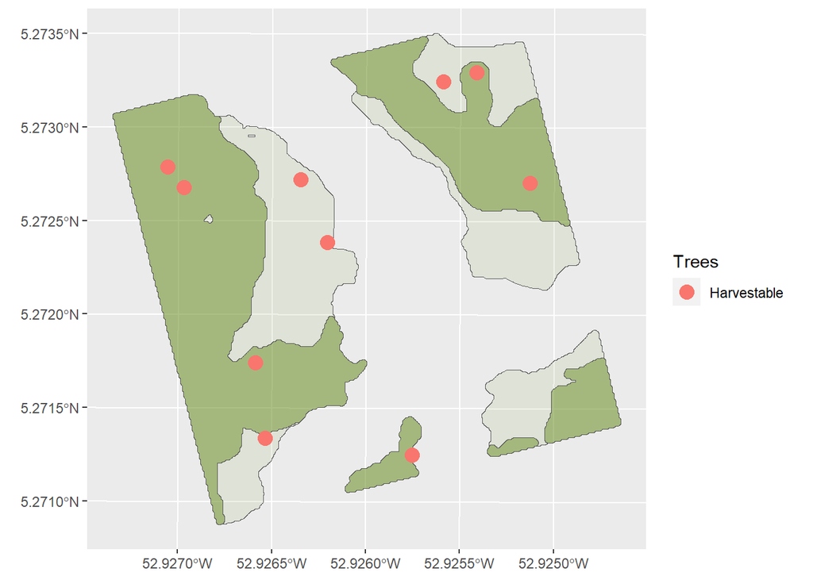

```r
LoggingMap +
  geom_sf(
    data = Harvestable,
    aes(colour = "Harvestable"),
    size = 4
  ) +
  labs(colour = "Trees")
```

Plot all designated trees.

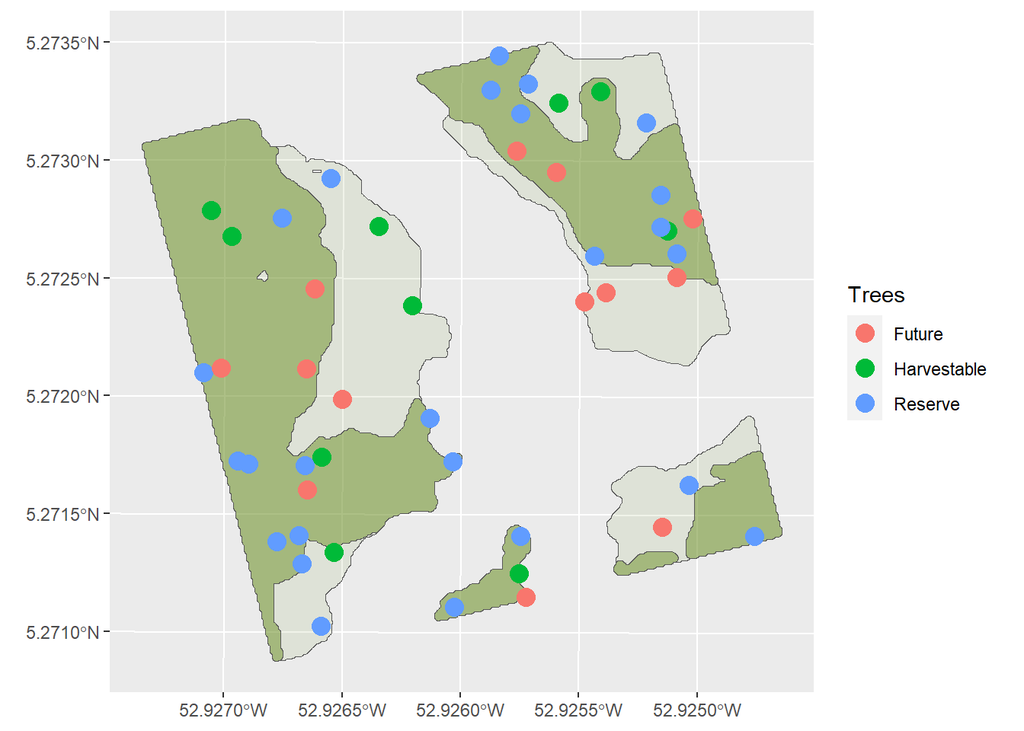

```r
LoggingMap +
  geom_sf(
    data = Harvestable,
    aes(colour = "Harvestable"),
    size = 4
  ) +
  geom_sf(
    data = Reserve,
    aes(colour = "Reserve"),
    size = 4
  ) +
  geom_sf(
    data = Future,
    aes(colour = "Future"),
    size = 4
  ) +
  labs(colour = "Trees") ->
  LoggingMap
LoggingMap
```

Add the tracks.

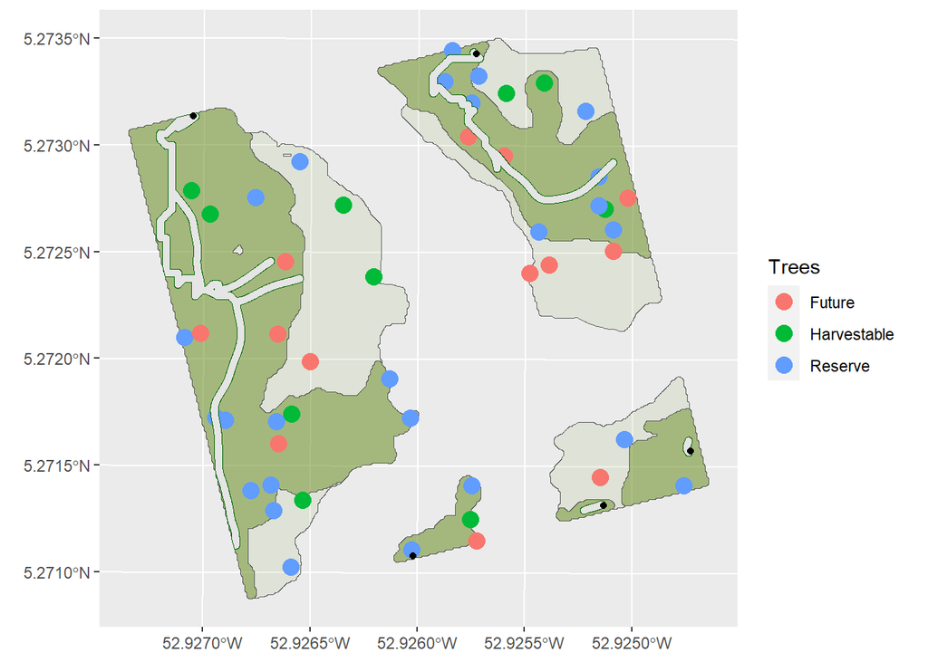

```r
LoggingMap +
  # 2ndary trails
  geom_sf(
    data = st_as_sf(SecondaryTrails$SmoothedTrails),
    col = "darkgreen"
  ) +
  geom_sf(
    data = st_as_sf(SecondaryTrails$MainTrailsAccess),
    col = "black"
  )
```

Access points are black.

## Tree felling

Simulate the tree felling, with the success or failure of the direction of the tree fall, foot to the trail, with an angle to the trail and avoiding the trees to protect, as desired. If fuel wood is exploited, the tree will be directed with its crown towards the trail (if the orientation is successful) so that it can be retrieved with a grapple.

The felling of the tree creates a tree (including crown) on the ground, with dimensions calculated by specific allometries (`advancedloggingparameters`). The process depends on the scenario. For example, scenarios without fuel wood imply:

- with 60% (`TreefallSuccessProportion`) probability: base of the tree towards the nearest trail.
- with 40% probability: random fall.

We choose `fuel = "2"`: exploitation of hollow trees, damages and and unused part of the logs. The trees will be recovered from the crown with a grapple if possible. If not, recovery will be from the base of the pole with a cable at an angle to the trail.

```r
inventory %>%
  treefelling(
    scenario = "manual",
    fuel = "2",
    winching = "2",
    directionalfelling = "2",
    maintrailsaccess = ScndTrailOutputs$MainTrailsAccess,
    scndtrail = ScndTrailOutputs$SmoothedTrails,
    advancedloggingparameters = loggingparameters()
  ) ->
  inventory
```

## Adjust secondary skidding tracks

If fuel wood is exploited, the layout of the skidding trails is redefined to favour the recovery of trees by the crown (only with a grapple) in order to use the crowns for fuel wood.

```r
ScndTrailAdjustOutputs <-
  secondtrailsadjusted(
    inventory,
    topography = DTMParacou,
    plotmask = PlotMask,
    maintrails = MainTrails,
    plotslope = HarvestableArea$PlotSlope,
    harvestablepolygons = Harvestable$HarvestablePolygons,
    machinepolygons = HarvestableArea$MachinePolygons,
    maintrailsaccess = ScndTrailOutputs$MainTrailsAccess,
    scenario = "manual",
    winching = "2",
    advancedloggingparameters = loggingparameters()
  )
```

## Post-logging map

We make a map with all trees, including felled ones.

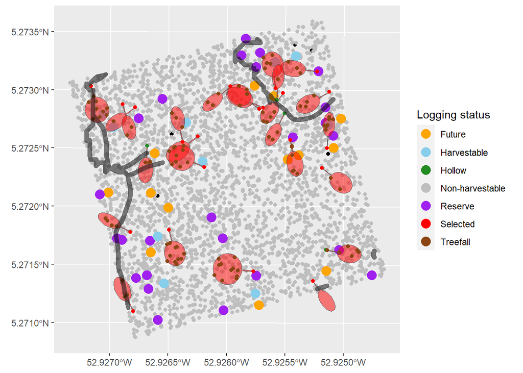

```r
# Selected trees
inventory %>%
  filter(Selected == "1") %>%
  st_as_sf(coords = c("Xutm", "Yutm")) %>%
  st_set_crs(st_crs(SecondaryTrails$MainTrailsAccess)) ->
  Selected

# Hollow
inventory %>%
  filter(ProbedHollow == "1") %>%
  st_as_sf(coords = c("Xutm", "Yutm")) %>%
  st_set_crs(st_crs(SecondaryTrails$MainTrailsAccess)) ->
  Hollow

# Treefalls
inventory %>%
  filter(Treefall2ndDeath == "1") %>%
  st_as_sf(coords = c("Xutm", "Yutm")) %>%
  st_set_crs(st_crs(SecondaryTrails$MainTrailsAccess)) ->
  Treefall

# Make an sf with inventory
inventory %>%
  sf::st_as_sf(coords = c("Xutm", "Yutm")) %>%
  sf::st_set_crs(sf::st_crs(MainTrails)) ->
  Inventory_crs

# Make an sf with felled trees
inventory %>%
  getgeometry(TreePolygon) %>%
  sf::st_set_crs(sf::st_crs(MainTrails)) ->
  TreePolygon

# Make a map
ggplot() +
  geom_sf(data = Inventory_crs) +
  geom_sf(data = NonHarvestable, aes(colour = "Non-harvestable"), show.legend = "point") +
  geom_sf(data = Future, aes(colour = "Future"), size = 4, show.legend = "point") +
  geom_sf(data = Reserve, aes(colour = "Reserve"), size = 4, show.legend = "point") +
  geom_sf(data = Harvestable, aes(colour = "Harvestable"), size = 4, show.legend = "point") +
  # Felled trees
  geom_sf(data = TreePolygon, alpha = 0.5, fill = "red") +
  geom_sf(data = Selected, aes(colour = "Selected"), show.legend = "point") +
  geom_sf(data = Hollow, aes(colour = "Hollow"), show.legend = "point") +
  geom_sf(data = Treefall, aes(colour = "Treefall"), show.legend = "point") +
  geom_sf(data = SecondaryTrails$maintrailsaccess, alpha = 0.5, fill = "black") +
  geom_sf(data = SecondaryTrails$SmoothedTrails, alpha = 0.5, fill = "black") +
  scale_colour_manual(
    values = c(
      "Non-harvestable" = "grey",
      "Visible defect" = "pink",
      "Harvestable" = "skyblue",
      "HarvestableUp" = "blue",
      "Selected" = "red",
      "Future" = "orange",
      "Reserve" = "purple",
      "Hollow" = "forestgreen",
      "Treefall" = "chocolate4"
    )
  ) +
  labs(color = "Logging status")
```

## Quantify the logged volumes

### Timber

Compute the timber harvested volume in healthy trees exploited for timber, and in the hollow trees if they are also harvested for fuel wood.

```r
TimberV <- timberharvestedvolume(
  inventory,
  scenario = "manual",
  fuel = "2",
  advancedloggingparameters = loggingparameters()
)
inventory <- TimberV$inventory
TimberV
```

```
## $inventory
## # A tibble: 3,525 × 71
##    Forest  Plot  PlotArea SubPlot idTree Protocole Xfield Yfield UTMZone   Lat
##    <chr>   <chr>    <dbl>   <int>  <int> <chr>      <dbl>  <dbl>   <int> <dbl>
##  1 Paracou 6         6.25       4 104455 Guyafor    215     69.5      22  5.27
##  2 Paracou 6         6.25       4 103939 Guyafor    128.    34        22  5.27
##  3 Paracou 6         6.25       2 102249 Guyafor    202    134.       22  5.27
##  4 Paracou 6         6.25       2 102086 Guyafor    176.   182.       22  5.27
##  5 Paracou 6         6.25       1 100904 Guyafor     36    170        22  5.27
##  6 Paracou 6         6.25       3 103694 Guyafor    122    116.       22  5.27
##  7 Paracou 6         6.25       1 101090 Guyafor     67.5  138        22  5.27
##  8 Paracou 6         6.25       1 101193 Guyafor     75.5  208.       22  5.27
##  9 Paracou 6         6.25       1 100833 Guyafor     25    238.       22  5.27
## 10 Paracou 6         6.25       1 101474 Guyafor    106.   238.       22  5.27
## # ℹ 3,515 more rows
## # ℹ 61 more variables: Lon <dbl>, Family.x <chr>, ScientificName <chr>,
## #   Genus <chr>, Species <chr>, BotaSource <chr>, BotaCertainty <dbl>,
## #   VernName <chr>, CensusYear <int>, CensusDateCertainty <lgl>,
## #   CodeAlive <lgl>, MeasCode <int>, Circ <dbl>, CircCorr <dbl>,
## #   CorrCode <chr>, DBH <dbl>, TreesIn <chr>, Xutm <dbl>, Yutm <dbl>,
## #   TreeHarvestableVolume <dbl>, TrunkHeight <dbl>, TreeHeight <dbl>, …
##
## $TimberLoggedVolume
## [1] 104.9446
##
## $NoHollowTimberLoggedVolume
## [1] 94.76655
```

Details of the yield by species is in the inventory.

```r
TimberV$inventory %>%
  # Cut trees
  filter(DeathCause == "cut") %>%
  # Group by commercial name
  group_by(CommercialName) %>%
  # Number of trees, timber volume and commercial level
  summarise(
    trees_n = n(),
    volume = sum(TimberLoggedVolume),
    CommercialLevel = unique(CommercialLevel)
  )
```

```
## # A tibble: 6 × 4
##   CommercialName trees_n volume CommercialLevel
##   <chr>            <int>  <dbl>           <dbl>
## 1 angélique            1   8.89               1
## 2 grignon franc        3  16.1                1
## 3 maho noir            4  16.5                2
## 4 wacapou              1   3.61               1
## 5 wapa                 7  28.2                2
## 6 wapa courbaril       5  21.5                2
```

### Fuel wood

Compute the harvestable fuel wood biomass in healthy trees exploited for timber (their unused part), in the hollow trees and in the damaged trees (caused by tracks and secondary windfalls). Computes also the the unused degraded tree biomass.

```r
FuelV <- harvestablefuelwood(
  inventory,
  scenario = "manual",
  fuel = "2",
  TimberLoggedVolume = TimberV$TimberLoggedVolume,
  NoHollowTimberLoggedVolume = TimberV$NoHollowTimberLoggedVolume,
  advancedloggingparameters = loggingparameters()
)
inventory <- FuelV$inventory
```

# Quick Logging simulation

## A single simulation

All simulations steps can be included in a single function to save time.

```r
Rslt <- loggingsimulation1(
  Paracou6_2016,
  plotmask = PlotMask,
  topography = DTMParacou,
  creekverticaldistance = CreekDistances$distvert,
  creekhorizontaldistance = CreekDistances$disthorz,
  speciescriteria = SpeciesCriteria,
  volumeparameters = ForestZoneVolumeParametersTable,
  scenario = "manual",
  objective = 30,
  fuel = "2",
  winching = "2",
  directionalfelling = "2",
  diversification = TRUE,
  specieslax = FALSE,
  objectivelax = TRUE,
  crowndiameterparameters = ParamCrownDiameterAllometry,
  advancedloggingparameters = loggingparameters()
)
```

Several simulations can be run by the function `loggingsimulation()` to take stochasticity into account with argument `iter` (number of simulations) and `cores` (number of computer cores used to parallelize the computation).

## Results

Return a summary of the outputs of the logging simulation function.

```r
loggingsummary1(Rslt)
```

```
## inventory : Paracou6_2016
## scenario : manual
## objective : 30 m3/harvestable ha
## fuel : 2
## diversification : TRUE
## winching : 2
## directionalfelling : 2
## specieslax : FALSE
## objectivelax : TRUE
## Harvestable area : 3.75 ha
## Objective volume : 112.4 m3
## Initial harvestable volume : 183.7 m3,  49 m3/harvestable ha
## Timber logged volume : 104.4 m3,  27.9 m3/harvestable ha
## No hollow timber logged volume : 88.5 m3,  23.6 m3/harvestable ha
## Timber extracted volume (timber volume after purge : 92 m3,  24.6 m3/harvestable ha
## Fuel wood biomass : 138.3 ton,  36.9 ton/harvestable ha
## Logging residual biomass : 63.1 ton,  16.9 ton/harvestable ha
## Total forest biomass lost : 273.9 ton
## Trails density : 99.5 m/ha
## Adjusted trails density : 93.5 m/ha
##
## Please note that all volumes in m3/ha are per exploitable hectare, not per plot hectare.
```

# References

Badouard, Vincyane, Sylvain Schmitt, Guillaume Salzet, Thomas Gaquiere, Margaux Rojat, Caroline Bedeau, Olivier Brunaux, and Géraldine Derroire. 2024. “LoggingLab: An R Package to Simulate Reduced-Impact Selective Logging in Tropical Forests Using Forest Inventory Data.” *Ecological Modelling* 487 (January): 110539. https://doi.org/10.1016/j.ecolmodel.2023.110539.